# Assignment 6: Visualization - Aesthetic Mapping

*How to do it?*:

- Open the Rmarkdown file of this assignment (link) in Rstudio.
- Right under each **question**, insert a code chunk (you can use the hotkey `Ctrl + Alt + I` to add a code chunk) and code the solution for the question.
- `Knit` the rmarkdown file (hotkey: `Ctrl + Alt + K`) to export an html.
- Publish the html file to your Githiub Page.

*Submission*: Submit the link on Github of the assignment to Canvas.

### Questions on Your Selected Data

Choose a dataset and produce the following types of plots and comment on each plot. Plots should be meaningful. If you use the data we used in class, make sure the plots are not the same as the ones in the slides.

```r
library(tidyverse)
library(ggplot2)
df <- read_csv('https://bryantstats.github.io/math421/data/adult_census.csv')
```

1. For one continuous variable:
- Density

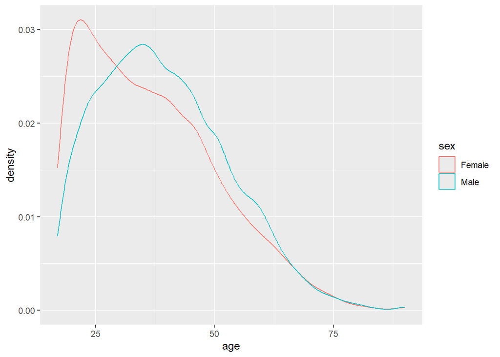

```r
df %>% ggplot()+
  geom_density(mapping = aes(x = age, color=sex))
```

```r
#This plot displays the distribution of males and females along with their ages. Here we can see that their is a higher group of younger females than males.
```

- Histogram

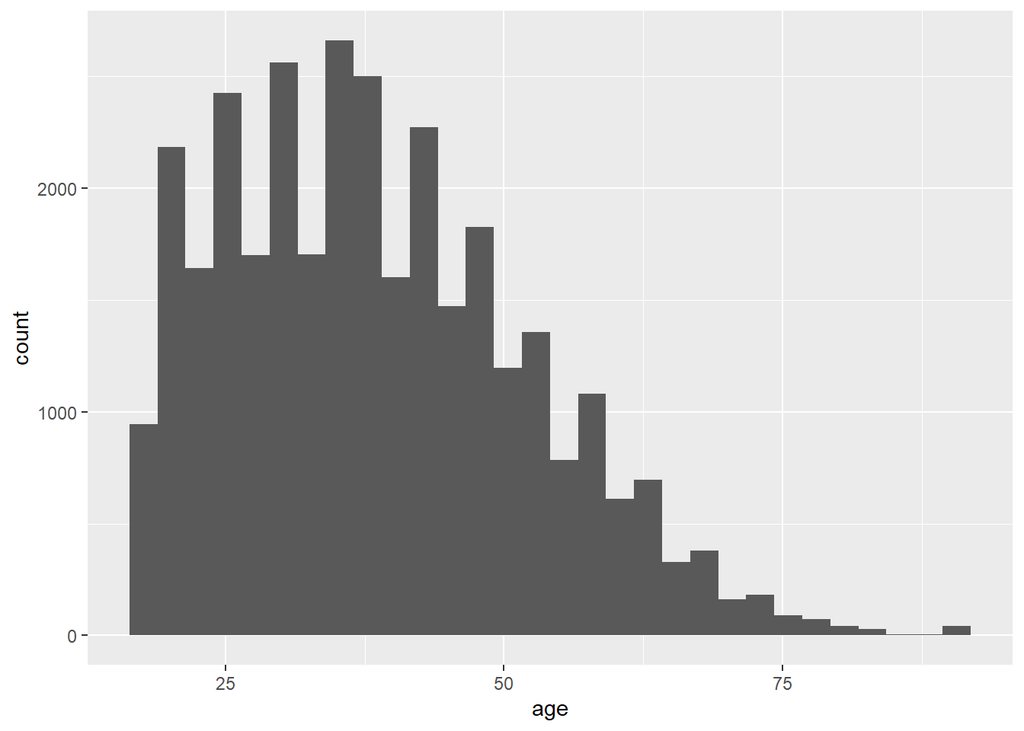

```r
df %>% ggplot()+
  geom_histogram(mapping = aes(x = age))
```

```r
#Using this histogram chart we can see that the majority of the data consists of people under 50 with the most being in their upper 30s.
```

- Boxplot

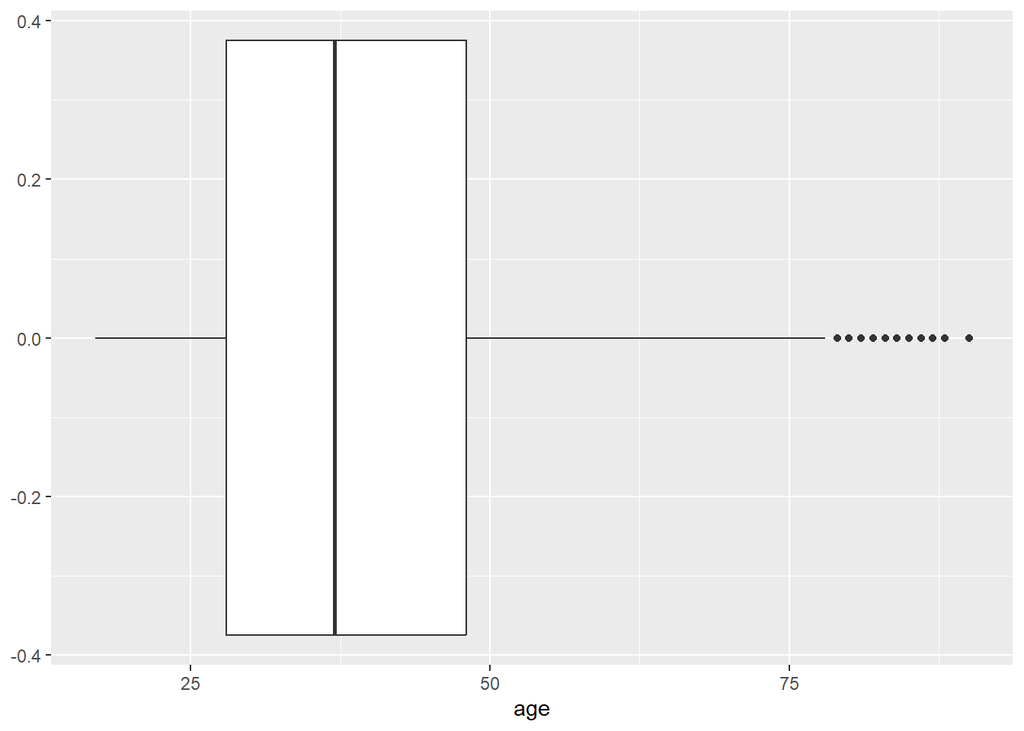

```r
df %>% ggplot()+
  geom_boxplot(mapping = aes(x = age))
```

```r
#This boxplot is another way to visualize the distribution of age. Again, the average age is in the range of 30s which makes sense based off of the histogram above.
```

2. For one categorical variable
- Barplot

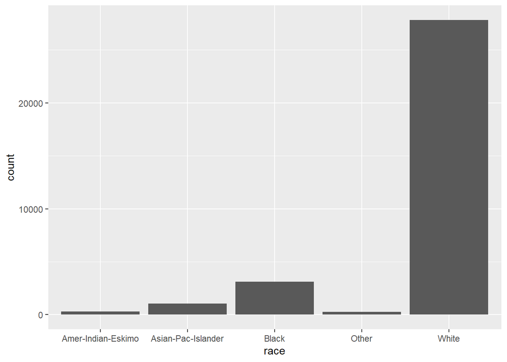

```r
df %>% ggplot()+
  geom_bar(mapping = aes(x =race))
```

```r
#This barplot allows us to see the breakout of the different kinds of races within this data set. From this we can conclude that the white race makes up the majority of the data.
```

3. For two continuous variables
- Scatter Plot

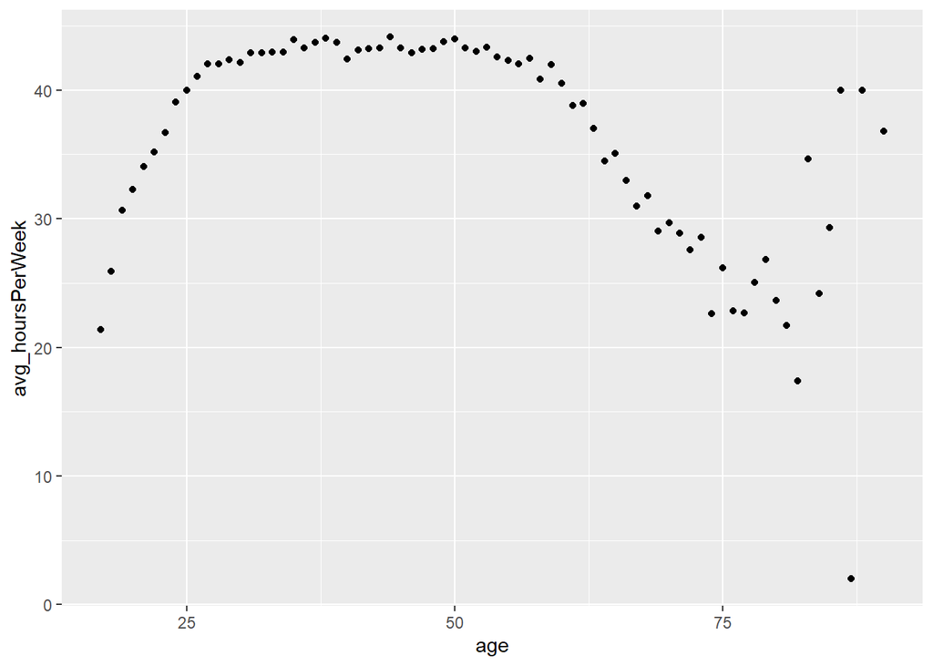

```r
df %>%
  group_by(age) %>%
  summarize(avg_hoursPerWeek = mean(hours.per.week)) %>%
  ggplot()+geom_point(aes(x=age, y=avg_hoursPerWeek))
```

```r
# Within this visual we wanted to find the average hours per week that someone worked based off of the average by their age. From this visual we can conclude that most people work 40 hours a week starting around 25 and slowly decrease once they turn roughly 62.
```

- Line Plot

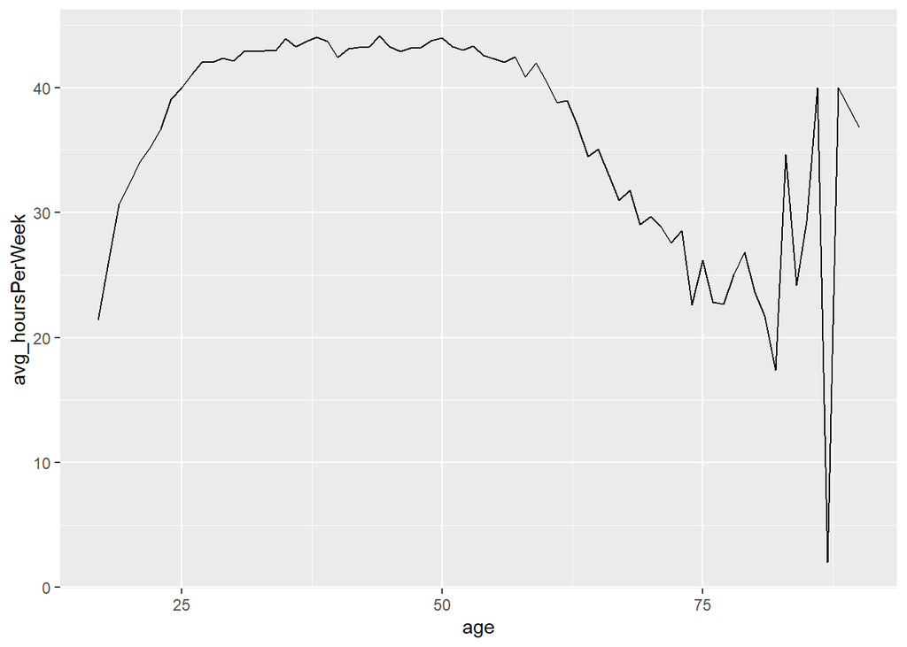

```r
df %>%
  group_by(age) %>%
  summarize(avg_hoursPerWeek = mean(hours.per.week)) %>%
  ggplot()+geom_line(aes(x=age, y=avg_hoursPerWeek))
```

```r
#This graph is very similar to the scatter plot above with wanting to find the average hours per week that someone worked based off of the average by their age
```

- Smooth Plot

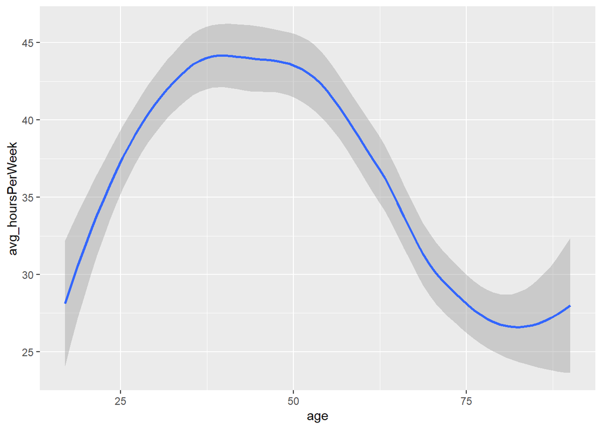

```r
df %>%
  group_by(age) %>%
  summarize(avg_hoursPerWeek = mean(hours.per.week)) %>%
  ggplot()+geom_smooth(aes(x=age, y=avg_hoursPerWeek))
```

```r
#This graph helps visualize the average amount of hours per week a person work fro each age. Here you can notice that most people are working over 40 hours a week from ages 35 to 55ish.
```

4. For one continuous + one categorical variables
- Density

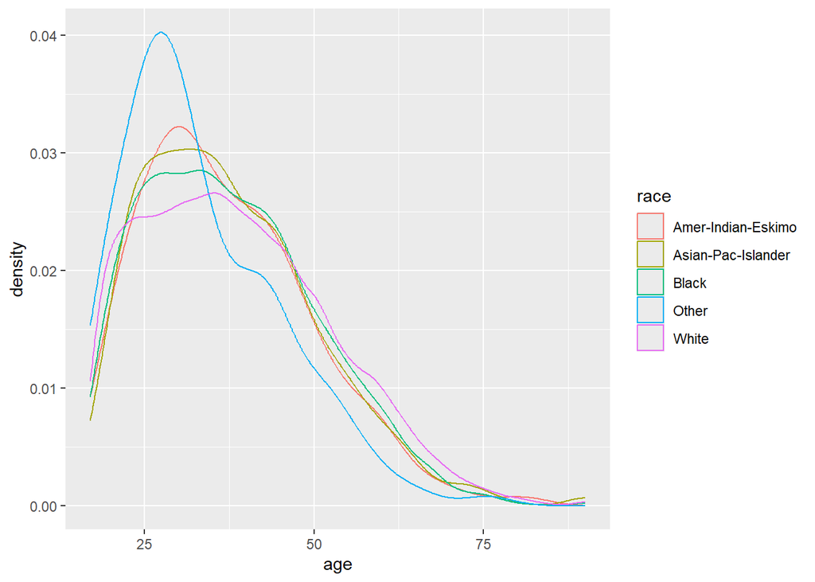

```r
df %>% ggplot()+
  geom_density(mapping = aes(x = age, color = race))
```